# Histogram Analysis

- Histograms are one of the most powerful ways to visualize data because they provide a clear view of the distribution of values within a dataset.
- By grouping data into bins, histograms reveal the shape of the distribution, highlight central tendencies, identify potential outliers, and illustrate variability.
- This visual summary makes it easier to compare different sets of data and spot trends or anomalies that might not be apparent through summary statistics alone.

```python
import os
import warnings
import logging

# configure logging
logging.basicConfig(
    level=logging.INFO, format="%(asctime)s [%(levelname)s] %(message)s", datefmt="%H:%M:%S",
)
logger = logging.getLogger(__name__)

# get warning filter policy from the environment variables
# set to "ignore" for rendering the HTMLs, or to "once" otherwise
WARNING_FILTER_POLICY = os.getenv("WARNING_FILTER_POLICY", "once")
logger.info(f"{WARNING_FILTER_POLICY = }")
warnings.filterwarnings(WARNING_FILTER_POLICY)
```

```
21:12:45 [INFO] WARNING_FILTER_POLICY = 'ignore'
```

```python
import numpy as np
import pandas as pd
import seaborn as sns

pd.set_option("display.max_columns", None)
pd.options.display.float_format = "{:,.2f}".format
```

```python
from utils.constants import RANDOM_SEED
from utils.common import (
    get_data_folder_path,
    set_plotting_config,
    plot_histogram,
    plot_comparison_histograms
)
```

```python
# plots configuration
sns.set_style("darkgrid")
sns.set_palette("colorblind")
set_plotting_config()
%matplotlib inline
```

## 1. Load Data

In this notebook, we will use the **Medical Insurance Payout Dataset**. This dataset contains historical data for over 1300 insurance customers (age, sex, BMI, number of children, smoking habits, and region) along with their actual medical charges. i.e., the expenditure for the customer.

Sources:

1. Kaggle: https://www.kaggle.com/datasets/harshsingh2209/medical-insurance-payout
2. Original source: https://raw.githubusercontent.com/JovianML/opendatasets/master/data/medical-charges.csv

```python
data_path = get_data_folder_path()

df_input = pd.read_csv(os.path.join(data_path, "expenses.csv"))
```

## 2. Plot Histograms

### Distribution of Medical Charges

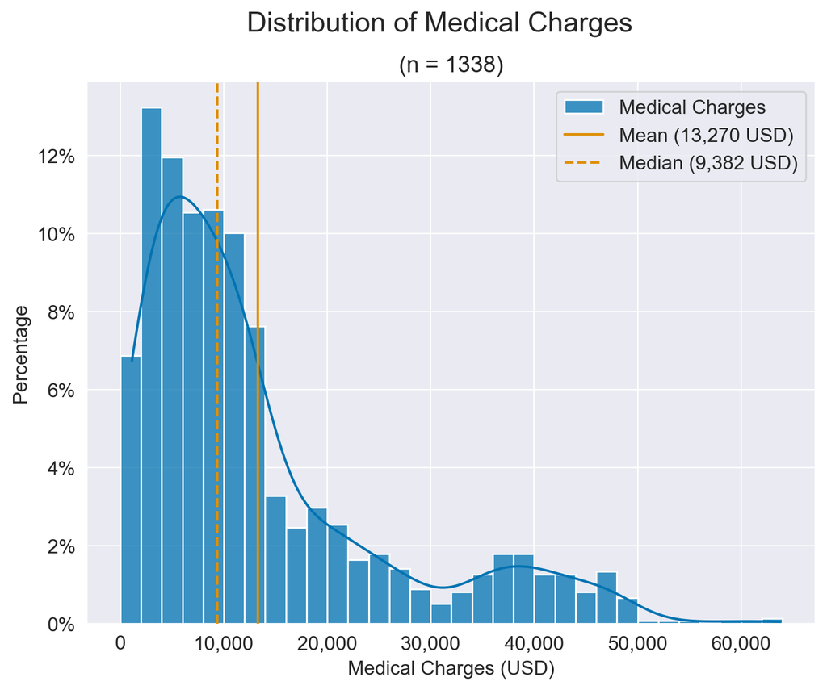

```python
fig1 = plot_histogram(
    title="Distribution of Medical Charges",
    histogram_title=f"(n = {len(df_input)})",
    df=df_input,
    plot_col="charges",
    display_name="Medical Charges",
    display_unit="USD",
    bin_size=2000,
    linewidth=1.5,
    show_legend=True,
    show_percentage=True,
    show_mean=True,
    show_median=True,
    show_zero_line=False,
    show_kde=True,
    figsize=(8, 6),
)
display(fig1)
```

### Distribution of Medical Charges by Smoking Status

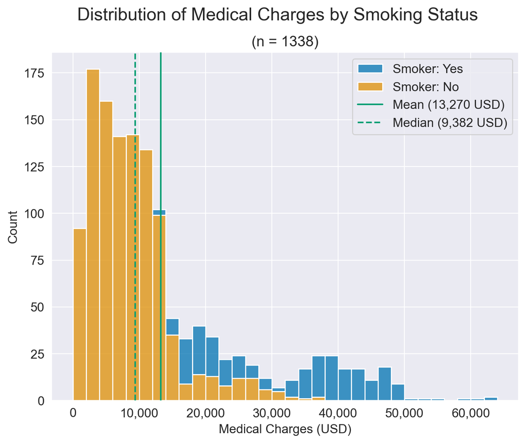

```python
fig2 = plot_histogram(
    title="Distribution of Medical Charges by Smoking Status",
    histogram_title=f"(n = {len(df_input)})",
    df=df_input,
    plot_col="charges",
    display_name="Medical Charges",
    display_unit="USD",
    stratify_col="smoker",
    bin_size=2000,
    linewidth=1.5,
    show_legend=True,
    show_mean=True,
    show_percentage=False,
    show_median=True,
    show_zero_line=False,
    show_kde=False,
)
display(fig2)
```

### COVID impact on Medical Charges

Let's do a (hypothetical) simulation of the impact of an event such as COVID-19 on the distribution of medical charges. Let's assume that COVID caused the average medical charge to increase by ~10% for all insurance customers in the database

```python
# create a random normal distribution with mean 1.1 (+10%) and std 0.1
np.random.seed(RANDOM_SEED)
random_change = np.random.normal(loc=1.1, scale=0.1, size=len(df_input))
# apply the random change to the charges to simulate COVID's impact
df_input["charges_new"] = df_input["charges"] * random_change
# calculate the difference
df_input["charges_diff"] = df_input["charges_new"] - df_input["charges"]
```

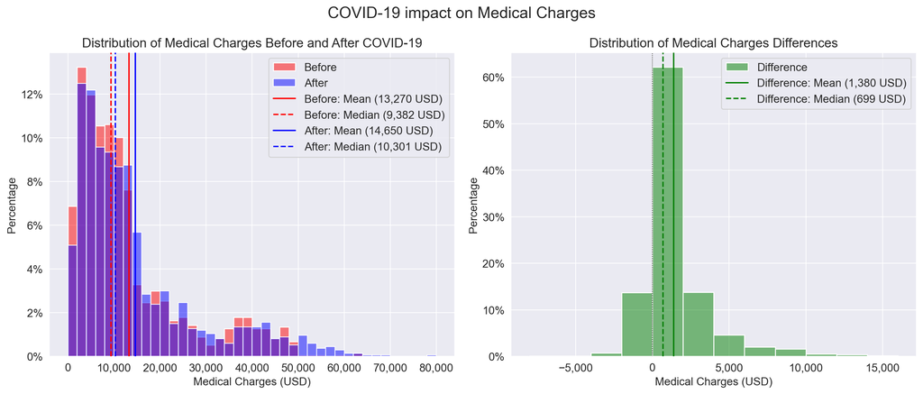

```python
plot_comparison_histograms(
    title="COVID-19 impact on Medical Charges",
    left_title="Distribution of Medical Charges Before and After COVID-19",
    right_title="Distribution of Medical Charges Differences",
    df=df_input,
    plot_col_before="charges",
    plot_col_after="charges_new",
    plot_col_diff="charges_diff",
    display_name="Medical Charges",
    display_unit="USD",
    bin_size=2000,
    show_percentage=True,
    show_mean=True,
    show_median=True,
    figsize=(14, 6),
)
```